# Analysis of Environmental Data Lab

Lab 08: Modeling Data 1

# Lab Credits

In addition to my original materials, this lab contains material adapted from Kevin McGarigal’s ECO 634 course.

Kevin taught this course for many years and his lab and lecture materials are an invaluable resource!

# Data Files

You’ll need to retrieve the following files:

- `vegdata.csv`
- `bird.sub.csv`
- `hab.sub.csv`
- Save them in the `data` subdirectory of your main course RProject folder.

# Bootstrap: Continuous Data

In the Bootstrap lab (lab 7), you used bootstrap resampling to calculate confidence intervals and create a rarefaction curve.

In this lab, we’ll be using bootstrap resampling to explore sampling distributions of model parameters in the context of one and two sample difference of means tests.

## Bootstrap: Exploring the Alternative Hypothesis

> Recall that t-tests are useful when we have a *categorical* predictor with two levels and a continuous response variable.

## Penguin Data

We’ll use the `palmerpenguins` dataset again, but this time, let’s remove the Gentoo penguins

```r
require(palmerpenguins)
penguin_dat = droplevels(subset(penguins, species != "Gentoo"))
```

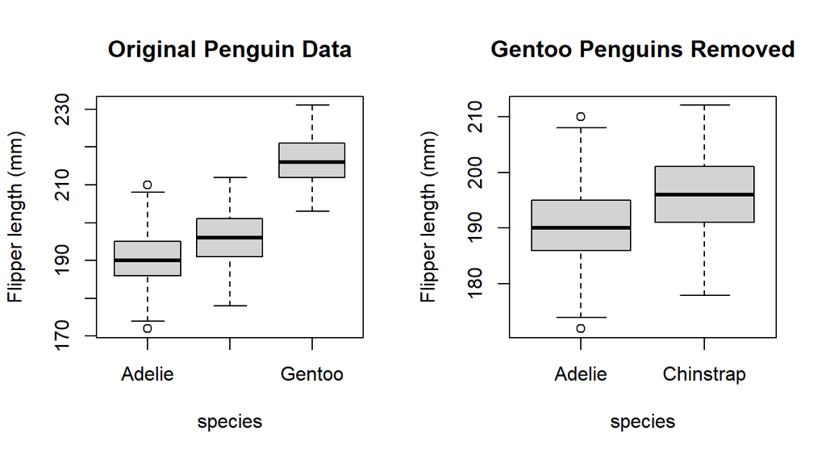

## Parametric Two-Sample Test

Perform a t-test with the alternative hypothesis that Adelie penguins have shorter flippers than Chinstrap penguins.

```r
t.test(flipper_length_mm ~ species, data = penguin_dat, alternative = "less")
```

```
##
##  Welch Two Sample t-test
##
## data:  flipper_length_mm by species
## t = -5.7804, df = 119.68, p-value = 3.025e-08
## alternative hypothesis: true difference in means is less than 0
## 95 percent confidence interval:
##       -Inf -4.186534
## sample estimates:
##    mean in group Adelie mean in group Chinstrap
##                189.9536                195.8235
```

Take note of the confidence interval, the p-value, and the group means.

## Bootstrap Two-Sample Test

In a previous lab you calculated bootstrap confidence intervals for the mean value of one group of observations.

You can also create a bootstrap confidence interval on the difference of two means… That sounds a lot like a t-test!

### Use `two.boot()`

You could write your own custom function to do a two-sample bootstrap, but you are already a whiz at writing functions so you can save some time by checking out `two.boot()` in the package `simpleboot`. Remember that you’ll have to install `simpleboot` before you can use any of its functions.

- Install the package.
- Look at the help entry for `two.boot()`.
- Conduct a bootstrap analysis of the difference in means of the two penguin species.
- I suggest using no more than 1000 replicates at first. If your computer is fast, you can increase the number of reps. Once you get your code right, y ou can run the simulation with 10000 iterations.

```
## List of 4
##  $ statistic: Named num 0.992
##   ..- attr(*, "names")= chr "W"
##  $ p.value  : num 0.811
##  $ method   : chr "Shapiro-Wilk normality test"
##  $ data.name: chr "rnorm(100)"
##  - attr(*, "class")= chr "htest"
```

```
## [1] 0.8112935
```

```
##     species flipper_length_mm
## 1    Adelie       0.720046617
## 2 Chinstrap       0.810644659
## 3    Gentoo       0.001619814
```

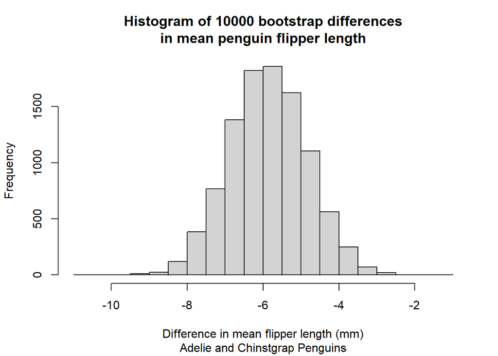

# Tree data

We’ll examine a dataset from a field experiment designed to assess tree seedling response to understory vegetation treatments.

Four treatments (including a control) were randomly assigned to 32 plots in a randomized block design. For now, we’ll not worry about the randomized block design part of the experiment.

For now, let’s consider just the number of pine seedlings (pine) under the various treatments.

Let’s visualize the data using box conditional boxplots plots:

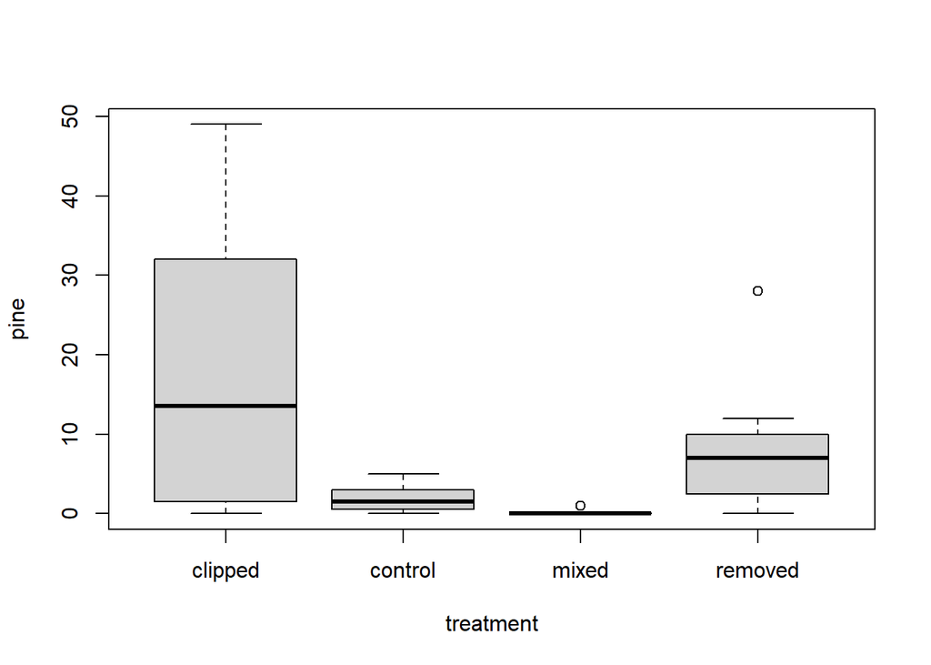

```r
boxplot(pine ~ treatment, dat = veg)
```

- What do you notice?

## Tree Treatments

Since we’re focusing on two-sample tests, let’s create a new data frame that contains only the observations that received the “clipped” or “control” treatments.

You can use the `subset()` function in conjunction with a new operator: `%in%`:

```r
dat_tree = droplevels(subset(veg, treatment %in% c("control", "clipped")))
```

- Don’t forget the call to `droplevels()`.

Create a new conditional boxplot on the new data to verify that your subsetting worked:

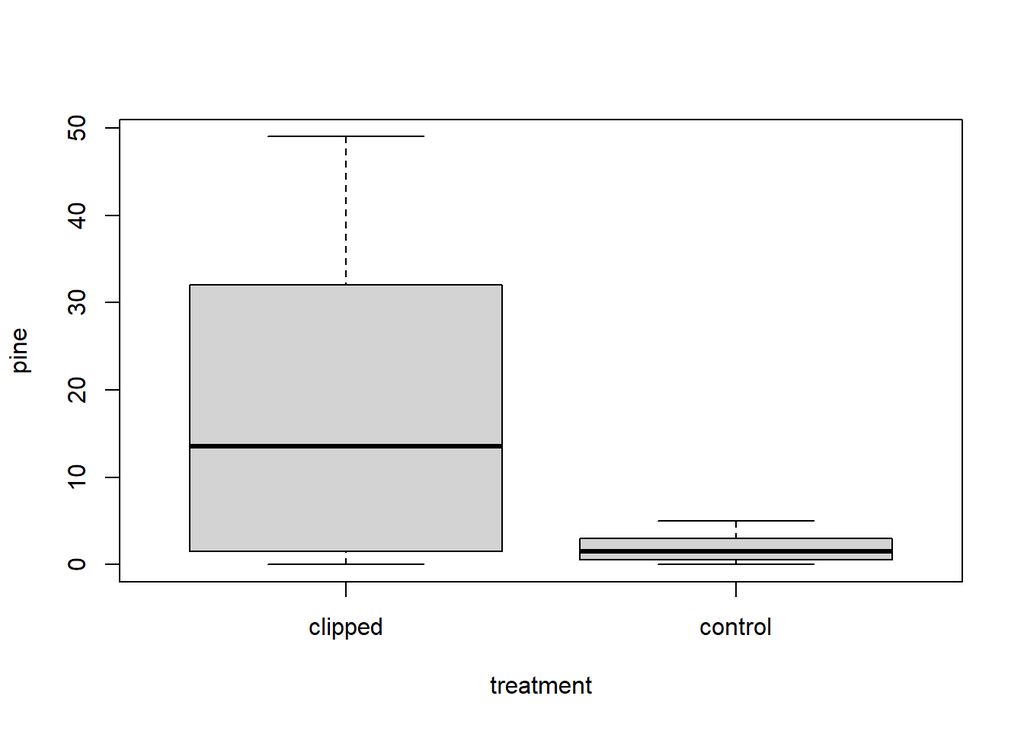

Use `table()` to determine how many observations are in each of the treatments. I’ll let you figure out the syntax. Hint: you’ll need to tell `table()` which column of the data to use.

## Nonparametric two-sample test

Conduct a Wilcoxon ranked sum test on the difference in means between the treatments.

- What was the p-value?

## Bootstrap

Conduct a bootstrap of the tree data.

- What are the endpoints of a 95% CI?

```r
tree_boot =
  two.boot(
    subset(dat_tree, treatment == "clipped")$pine,
    subset(dat_tree, treatment == "control")$pine,
    FUN = mean,
    R = 10000,
    na.rm = TRUE
  )

# sum(tree_boot$t >= 0)
# sum(tree_boot$t < 0)

boot.ci(tree_boot)
```

```
## BOOTSTRAP CONFIDENCE INTERVAL CALCULATIONS
## Based on 10000 bootstrap replicates
##
## CALL :
## boot.ci(boot.out = tree_boot)
##
## Intervals :
## Level      Normal              Basic
## 95%   ( 3.17, 28.73 )   ( 2.38, 27.62 )
##
## Level     Percentile            BCa
## 95%   ( 4.38, 29.62 )   ( 4.75, 30.38 )
## Calculations and Intervals on Original Scale
```

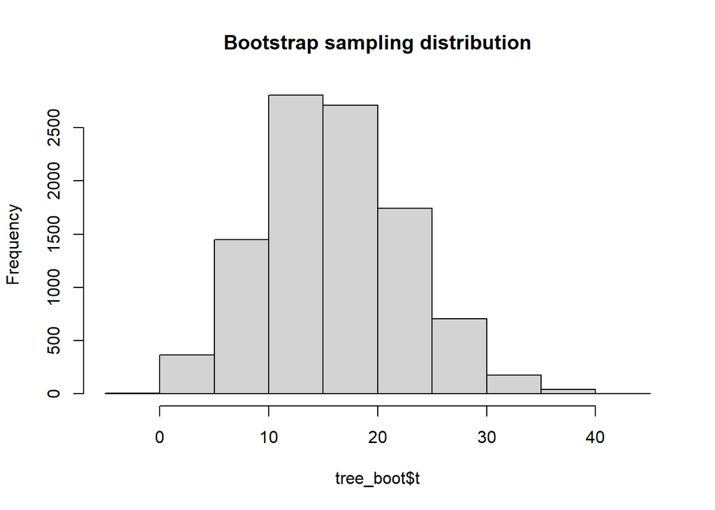

```r
hist(tree_boot$t, main = "Bootstrap sampling distribution")
```

```r
quantile(tree_boot$t, 0.025)
```

```
##  2.5%
## 4.375
```

# Resampling: linear regression

We can use Monte Carlo randomization to assess the significance of regression parameters.

We’ll estimate the significance of a slope parameter of a simple linear regression.

Although R’s `lm()` function produces a fitted model with parametric significance values for model coefficients, you may want to use other methods to assess significance. For example, if your data don’t meet the assumptions of a Frequentist linear regression, resampling techniques can sidestep some of the assumptions.

## Bird Data

We’ll use a standardized version of the Oregon birds data.

*Z-standardization* is a form of *normalization*.

When we modeling data that has values that span different orders of magnitude, normalizing ensures that the range of values for each variable span approximately the same range.

This is helpful for comparing model coefficients.

The data in the subbasin files (which we are using here) are aggregated by sub-basin from the full bird census count data we have used previously.

There are habitat variables for 30 subbasins.

You’ll need to retrieve the `bird.sub.csv` and `hab.sub.csv` files from the course github site (see the Data Files section above).

See the corresponding metadata file (birdhab.meta.pdf) for more info.

Read the data files and merge into a single `data.frame`:

```r
dat_bird = read.csv(rmd.utils::find_file("bird.sub.csv"))
dat_habitat = read.csv(rmd.utils::find_file("hab.sub.csv"))

dat_all = merge(
  dat_bird,
  dat_habitat,
  by = c("basin", "sub"))

head(dat_all[, c("b.sidi", "s.sidi")])
```

```
##       b.sidi s.sidi
## 1 0.06678912   0.12
## 2 0.06509689   0.34
## 3 0.06092608   0.78
## 4 0.06012721   0.57
## 5 0.04112905   0.84
## 6 0.06086158   0.73
```

Note that the `b.sidi` column values are about 1/10 the value of the `s.sidi` column.

R has functions for centering and standardizing data, but to illustrate the z-standardization process, we’ll do it manually. Don’t worry, it’s not very difficult to do!

Recall the process:

1. Calculate the sample mean and standard deviation.
2. Subtract the mean from each value.
3. Divide each value by the sample standard deviation.

Here’s how to do it for the `b.sidi` column. I’ll create a new column called `b.sidi.standardized`:

```r
# Calculate the sample mean and sd:
b_sidi_mean = mean(dat_all$b.sidi, na.rm = TRUE)
b_sidi_sd   = sd(dat_all$b.sidi, na.rm = TRUE)

# Use the subset-by-name symbol ($) to create a
# new column of z-standardized values.

dat_all$b.sidi.standardized = (dat_all$b.sidi - b_sidi_mean)/b_sidi_sd
```

Now, examine the standardized data to see if our standardization worked:

```r
mean(dat_all$b.sidi.standardized)
```

```
## [1] 7.166938e-17
```

```r
sd(dat_all$b.sidi.standardized)
```

```
## [1] 1
```

Note that $7.2 \times 10^{-17}$ is effectively 0.

- I’ll let you follow the pattern to standardize the `s.sidi` column.

In this case, the relational fields that link the bird and habitat data sets are:

- `basin` (3 unique basins)
- `sub` (10 unique sub-basins in each basin).

We are only going to use two of the many variables in the data.

## Model Variables

We’ll only be using two of the many variables in the merged data:

1. Simpson’s diversity index for breeding birds: `b.sidi`
2. Simpson’s diversity index for vegetation cover types: `s.sidi`

Note, the latter index represents the diversity in landscape composition as defined largely by vegetation seral (intermediate stages of succession) stage.

Let’s begin by plotting the data:

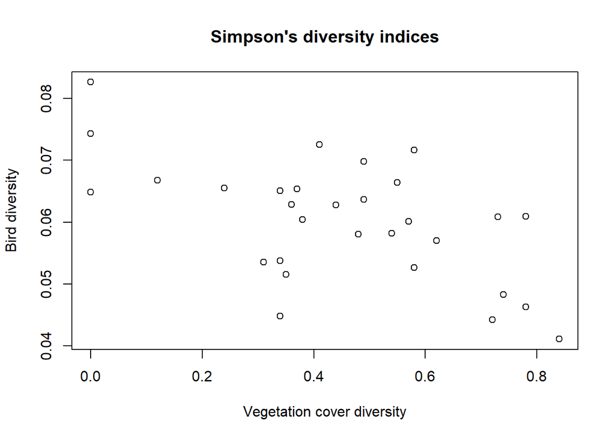

```r
plot(
  b.sidi ~ s.sidi, data = dat_all,
  main = "Simpson's diversity indices",
  xlab = "Vegetation cover diversity",
  ylab = "Bird diversity")
```

It appears that there is a negative relationship between bird diversity and vegetation diversity; specifically, bird diversity declines as the vegetation diversity increases.

This seems somewhat counter-intuitive, since we usually think of animal diversity increasing with the diversity of habitats (proxied here by vegetation seral stages).

Could this result have been due to chance?

Or is this relationship likely to be real?

## Simple Linear Regression

We can fit a simple linear regression using a Least Squares criterion.

We can examine the model coefficients with `coef()`. We’ll want to save the slope coefficient for later.

The slope coefficient is labeled `s.sidi` since that is the predictor we specify in the model.

```r
fit_1 = lm(b.sidi ~ s.sidi, data = dat_all)
coef(fit_1)
```

```
## (Intercept)      s.sidi
##  0.07116980 -0.02437131
```

```r
slope_observed = coef(fit_1)[2]
```

You can easily add a regression line from a model fitted by `lm()` to an existing plot using `abline()` and the fitted model object.

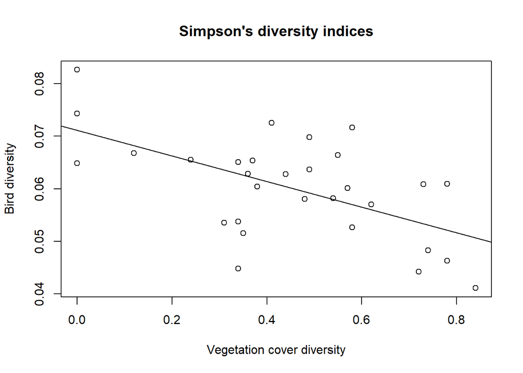

```r
plot(
  b.sidi ~ s.sidi, data = dat_all,
  main = "Simpson's diversity indices",
  xlab = "Vegetation cover diversity",
  ylab = "Bird diversity")
abline(fit_1)
```

## The Slope Coefficient

We would like to know how likely it is for us to observe a slope coefficient this large and negative if in fact there is no real relationship between bird diversity and vegetation diversity.

We can use the t statistic and corresponding p-value computed by the `lm()` function, but this assumes that the errors are normally distributed about the mean, which may or may not be the case here.

To be on the safe side, we are going to construct our own null hypothesis test using a Monte Carlo randomization procedure.

First, let’s simplify our data set by extracting just the two variables we need for this exercise:

```r
dat_1 =
  subset(
    dat_all,
    select = c(b.sidi, s.sidi))
```

- Note the use of the `select` argument!

## Resampling The Data

> Monte Carlo randomization breaks up the associations by sampling frandom values from each column, in stead of keeping rows intact.

To create a resampled dataset, we can create two vectors of randomly generated row indices. Then we can use these to create two new vectors of bird and vegetation diversity indices.

```r
index_1 = sample(nrow(dat_1), replace = TRUE)
index_2 = sample(nrow(dat_1), replace = TRUE)

dat_resampled_i =
  data.frame(
    b.sidi = dat_1$b.sidi[index_1],
    s.sidi = dat_1$s.sidi[index_2]
  )

fit_resampled_i = lm(b.sidi ~ s.sidi, data = dat_resampled_i)
slope_resampled_i = coef(fit_resampled_i)[2]

print(slope_resampled_i)
```

```
##       s.sidi
## 5.998737e-05
```

And we can re-create the scatterplot with regression line:

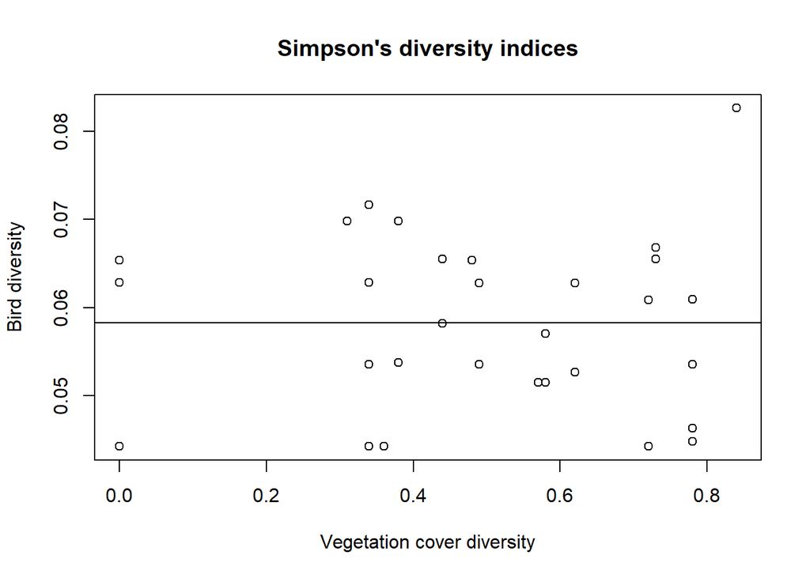

```r
plot(
  b.sidi ~ s.sidi, data = dat_resampled_i,
  main = "Simpson's diversity indices",
  xlab = "Vegetation cover diversity",
  ylab = "Bird diversity")
abline(fit_resampled_i)
```

We need to do this many times to see what the range of outcomes we expect to see by chance alone.

We know that because of sampling error, a single permutation could by chance have a slope that is different from nearly zero.

- Think of the sampling error like a book in the Library of Babel that happens to have several pages of perfect English!

## Randomization Loop

We can repeat the process many times to estimate the sampling distribution of the null hypothesis.

- I call it the distribution of the null because the null hypothesis states that there is no association between variables. We destroyed associations by shuffling both columns independently.

First we can pre-allocate a vector to hold the results using `numeric()`. Check out the help entry to find out more about `numeric()`.

```r
m = 10000
result = numeric(m)
```

Now it’s up to you to build a loop that will resample the data, fit a simple linear regression, and extract the slope parameter. Here’s a skeleton:

```r
for(i in 1:m)
{
  index_1 = sample(...,,)

  # ... your loop code ...

  result[i] = coef(fit_resampled_i)[2]
}
```

## The Null Distribution

The output of your loop is a collection of regression slope parameters that were calculated on randomized and resampled data.

Plot a histogram of the slope values.

- use `abline()` with the argument `v = slope_observed` to draw a vertical line showing the value of the slope from the regression model on the observed data.

Your result should look something like this:

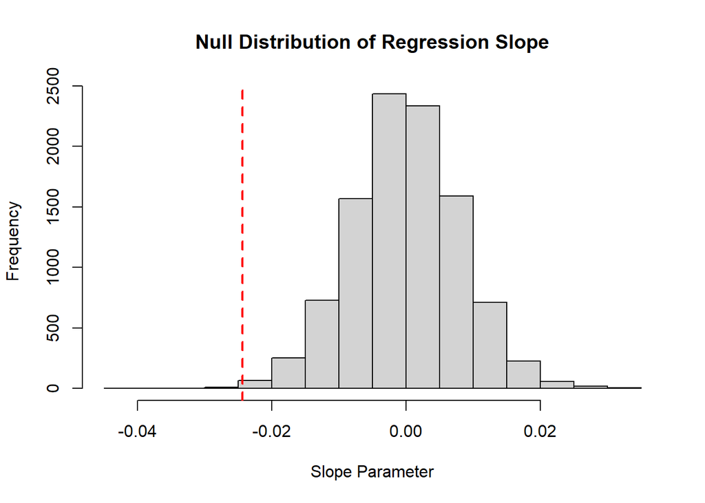

```r
hist(result, main = "Null Distribution of Regression Slope", xlab = "Slope Parameter")
abline(v = slope_observed, lty = 2, col = "red", lwd = 2)
```

## Critical Slope Value

Just like finding the critical z-value for confidence intervals, we can calculate a critical value for the slope.

- Use `quantile()` to find the 5th percentile of the null distribution of slopes.

In my simulation I got:

```r
quantile(result, c(.05))
```

```
##          5%
## -0.01337909
```

Do you remember what the observed slope of the real data was?

- How does it compare to the lower critical value?

How many slopes from the Monte Carlo randomization were equal to or less than the observed slope?

For my simulation, I found 18 slopes (out of 10000 simulations) generated from the null distribution that were equal to or less than the observed slope.

If we want an exact p-value for this lower one-side test, we can compute the percentage of the permuted distribution less than or equal to our observed slope value.

```
## [1] 0.0018
```

There you have it.

Convincing evidence that the slope we observed is real; i.e., that bird species diversity declines with increasing vegetation landscape diversity in this system.

Why this is so is another question you can ponder.

# Lab Questions

## Q1-4 Penguin Boot 1

1. Use the `two.boot()` function to calculate 10000 bootstrap replicates of the difference in mean flipper length of Chinstrap and Adelie penguins.
2. Is there missing data? If so, what argument have we used before in functions like `mean()` and `sd()` to exclude NA values?
3. Save the output of `two.boot()` to a variable called `pen_boot`. This is so that I can replicate your code easily on my machine for grading and assistance.
4. Plot a histogram of your bootstrapped differences.
5. Use `quantile()` with `pen_boot` to calculate a 95% Confidence interval on the difference in mean flipper lengths.
6. Calculate the *mean* and *median* difference in flipper lengths.
- Hint: you’ll need to investigate the structure of `pen_boot` to figure out what component contains the bootstrapped differences.
- **Q1 (1 pt.):** Calculate the standard deviation of the differences in mean flipper length from your bootstrap simulation. Show the R-code you used to find do the calculation.
- **Q2 (2 pts.):** Include your histogram in your lab report (you don’t need to show the R-code but make sure your plot includes appropriate title, axes, etc.).
- **Q3 (2 pts.):** What was the 95% bootstrap CI you calculated using `quantile()`? Show the R-code you used to answer the question.
- **Q4 (4 pts.):** Do you think the resampled differences in means follow a skewed distribution? Your answer should make reference to the *mean*, *median*, **and** *histogram* of the differences in means.

## Q5-7 - Penguin ECDF

1. Create a distribution function from `pen_boot` using `ecdf()`.
   - Name the function created by `ecdf()` `pen_ecdf`.
   - You can use the new function to calculate the cumulative density.
2. Use `pen_ecdf()` to calculate the empirical probability of observing a mean difference of -4.5 or greater.
3. Use `pen_ecdf()` to calculate the empirical probability of observing the mean difference predicted by the null hypothesis, i.e. 0 or greater.
   - Note we could also ask what is the probability of observing some value in the range of -1 to 1, for example.
   - We could even ask what is the probability of observing a value within the range of a 95% CI of the null hypothesis… We might even generate such a 95% CI of the null hypothesis using a Monte Carlo simulation!
   - This sounds a lot like Type I error rates, Type II error rates, and statistical power! We’ll be covering these in detail in lecture.

**ECDF Hints (click to show/hide)**

The `ecdf()` function is a little different than other functions that we’ve worked with because it returns a new function instead of an R data object.

- Recall that we used bootstrapping to characterize the sampling distribution of the *alternative hypothesis*.
- Remember the law of total probability and complementary events.
- `pen_ecdf()` is a lot like `pnorm()`. It calculates the area under the density curve *to the left* of x.
- Remember plots like this one that show the shaded area to the left of x for a standard normal distribution?
  - For this plot I have used $x = -0.5$.

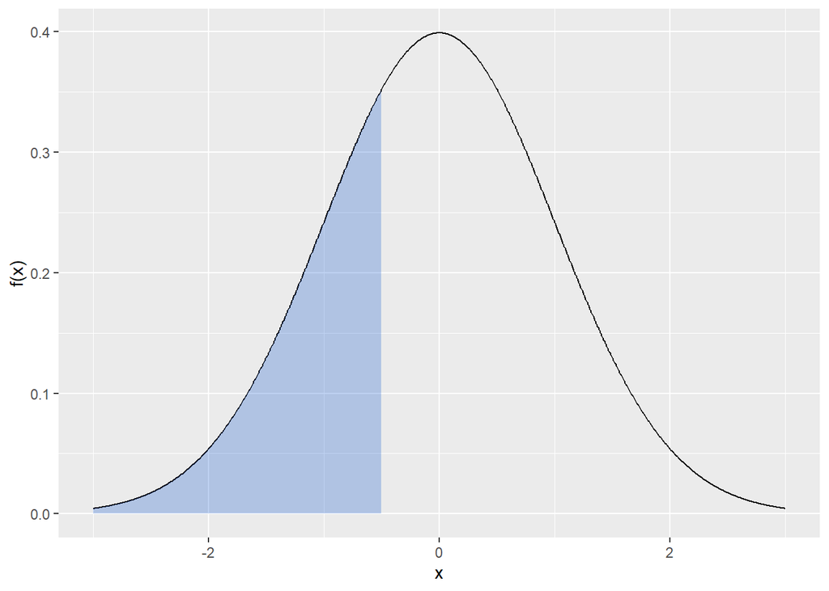

We get the area of the blue shaded area with `pnorm(-0.5)`, which turns out to be 0.3085375.

- The usage of `ecdf()` is very similar.
- **Q5 (2 pts.):** Show the R-code you used to create `pen_ecdf()`
- **Q6 (2 pts.):** What is the probability, according to the empirical distribution function, of observing a mean difference of -4.5 *or greater*? Show the R code you used to perform the calculation.
- **Q7 (2 pts.):** What is the probability, according to the empirical distribution function, of observing a mean difference of -8 *or smaller*? Show the R code you used to perform the calculation.

## Q8 Hypotheses

- Consider the alternative and null hypothesis for a two-sample, and two-tailed, test of the difference in mean flipper length between the two penguin species.
- **Q8 (3 pts.):** State the null and alternative hypotheses of a *two-sample*, *two-tailed* test for the difference in mean flipper lengths between the two penguin species.

## Q9 - Pines, Non-Parametric Test

1. Read the pine tree data into a `data.frame` called `veg`.
2. Check out the first few rows of the data to look at the column names and to see if there are any obvious issues with the data.
3. Use `droplevels` and `subset` to keep just the *control* and *clipped* levels of the *treatment* column.
4. Conduct a Wilcoxon ranked sum test on the difference in the mean number of pine seedlings between the *control* and *clipped* treatments.
5. Examine the output of the test.

To receive full credit, you must use the *formula* notation in R to conduct the test.

- **Q9 (2 pts.):** What was the p-value? Show the R-code you used to find out.

## Q10-11 Pines, Bootstrap

1. Use `two.boot()` to create a bootstrapped data set of the differences in mean tree count between the clipped and control treatments.
   - Save your results as `tree_boot`.
2. Use `quantile()` to find a 95% CI.
- **Q10 (1 pt.):** What were the endpoints of your bootstrap CI? Show the R-code you used to find out.
- **Q11 (1 pt.):** What is the observed difference in mean tree counts and does it fall within the 95% bootstrap CI?

## Q12-17 Resampling Model Coefficients

1. Z-standardize the `s.sidi` and `b.sidi` column of `dat_all`. Add the standardized data to `dat_all` using the new column names `s.sidi.standardized` and `b.sidi.standardized`.
2. Complete the code for a loop to resample the slope parameter of a simple linear regression of the Simpson’s diversity indices for vegetation and birds.
3. Use your loop to create a MC resampled vector of 10000 model slope parameters.
4. Plot a histogram of the MC simulated slope parameters.
5. Use `quantile` to find the 5% quantile of slopes in the null distribution. This is the critical value.
6. Use `abline()` along with the argument `v =` to add a vertical line showing where the observed slope occurred.
   - This line should be be blue, solid, and have a width of 2.0.
7. Use `abline()` along with the argument `v =` to add a vertical line showing the critical value.
   - This line should be be red, dotted, and have a width of 2.0.
- Do you remember how do z-standardize? Check out lecture slide deck 5 if you need a refresher.
- Consult the lab walkthrough for some help getting started.
- Hint: Recall how we have ‘wrapped up’ code into loops or functions before?
- Debugging and testing hint: Once you’ve created a working loop, clear out your R environment to make sure your loop runs correctly.
- Consult the R help and Dr. Google for help, as needed.
- **Q12 (2 pts.):** Briefly describe the Simpson diversity index, and explain what it quantifies.
- **Q13 (2 pts.):** Show the code you used to z-standardize the `s.sidi` column.
- **Q14 (6 pts.):** Show the code for your completed loop.
- **Q15 (2 pts.):** In your report, include a plot of your histogram with vertical lines showing the observed slope and the critical value from the resampled MC slopes.
- **Q16 (2 pts.):** What was your critical value? Was the observed slope less than the critical value?
- **Q17 (3 pts.):** What is your conclusion regarding the evidence of a negative relationship between vegetation cover diversity and bird diversity? Make sure to justify your conclusions using the results of your analysis.